# Bird Strike Data Analysis

## by (Ekwunife Mmesoma)

[figure not shown]

## Investigation Overview

> In this investigation, I focused on the states, airports and seasons that had the most bird strikes and damaged aircrafts. Further analysis also showed the bird species and size of species that caused it and the time across the different months that it occurred. I also included some recommendations at the end of this presentation that would help to curb the bird strikes.

## Dataset Overview

> The data consists of 45,000 bird strike cases in the United States from 1990 to 2021, including states, airports, longitude, latitude, size, etc. The variable, season was engineered for this analysis.

## What percent of the bird strike cases caused damage to the aircraft?

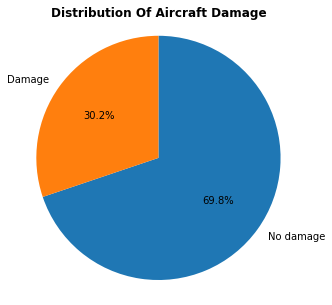

## Which top 10 Airport and States had the most aircraft damages?

California, Salt Lake City and Sacramento Intl airport were the states and airports with the most aircraft damages.

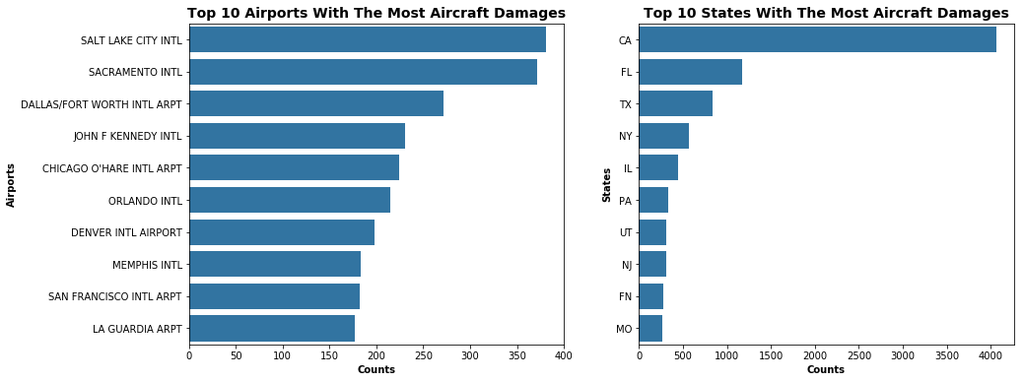

## Which top 10 bird species caused the most bird strikes and aircraft damage?

The species gulls, white-tailed deer and canada goose were the bird species that caused the most aircraft damages while the mourning dove, gulls and barn swallow caused most bird strikes.

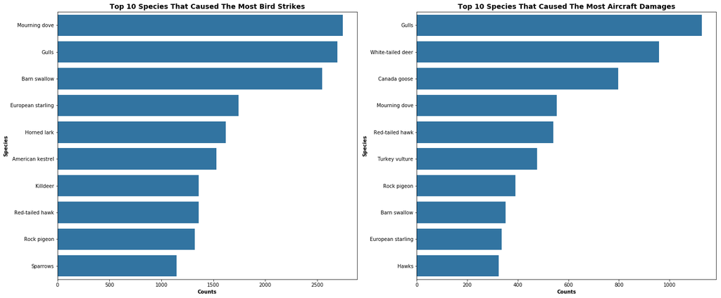

## Which season had the most aircraft damages and bird strikes?

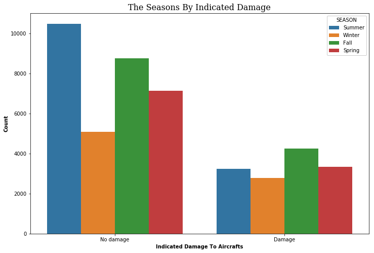

## What size of species caused the most aircraft damages and bird strikes?

The small sized birds caused the most bird strikes while the large sized birds caused the least bird strikes and the medium sized birds caused the most aircraft damages while the small sized birds caused the least aircraft damages.

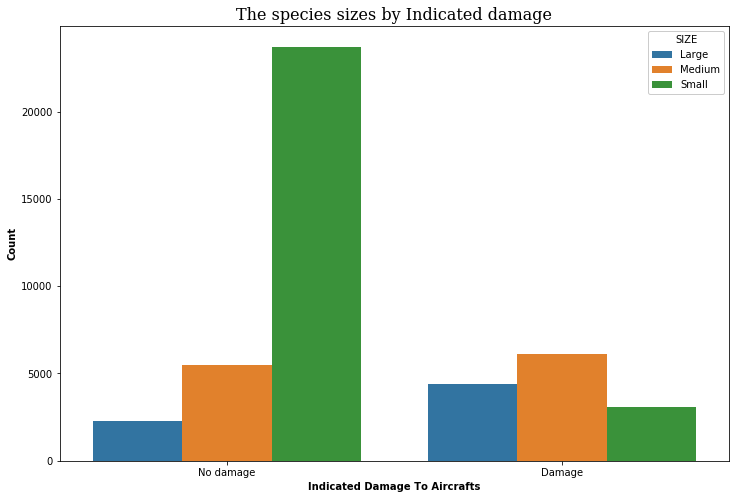

## What is the time distribution across different months of the year?

June, July, August, September, November, and December most frequent time range falls between 8-10 am while January and February most frequent time range falls between 10-11 am and April, October, March, and May time range falls between 22-23 pm.

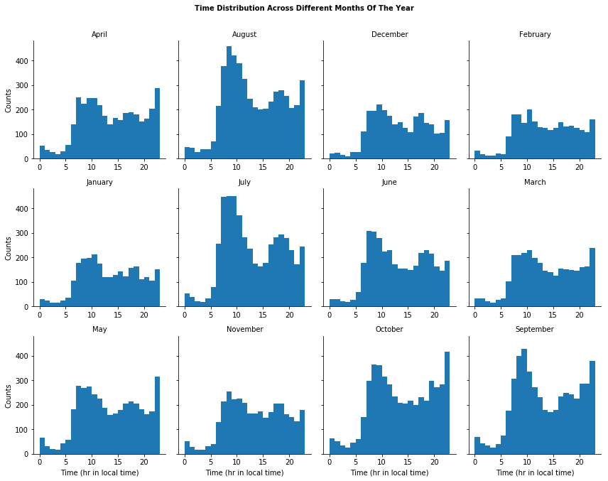

## Which bird species caused the most aircraft damage in terms of longitude and latitude?

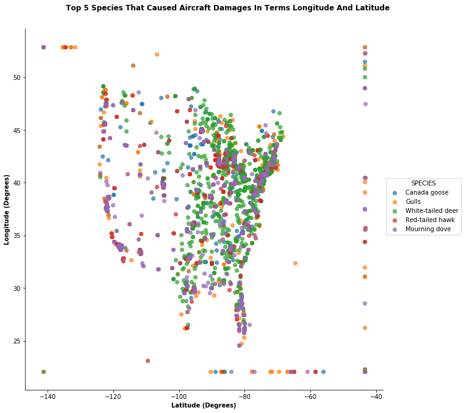

## Recommendations

- Flights should be rescheduled to exclude the times (8-10 am and 22-23 pm).
- Extra precautions should be put in place during the summer and fall season like hiring a bird specialist to specifically check things that scare these bird species (mourning dove, gulls, barn swallow, european starling, horned lark, white-tailed deer, canada goose and red-tailed hawk away.
- The Salt Lake City, Sacramento and Dallas/Fort Worth International Airport had the most aircraft damages and therefore measures should be put in place around the airport vicinity to curb bird strikes.
- More data from the minority class (where indicated damage = Damage) is needed to glean information from the data in order to avoid bias in analysis.